# Soil Transmitted Helminths in Kenya

# Introduction

Soil Transmitted Helminths are intestinal worms that are transmitted through feces. The feces of an infected person may contain the eggs of the worms. When an infected person defecates in an open area, or if the feces is used as manure, it may contaminate food or other items that humans may touch or consume. A person gets infected if they ingest the eggs. There are three types of helminths – Roundworms, Whipworms and Hookworms (CDC, 2022).

The focus of this study is on STH infections in Kenya. Worm in Kenya are a significant public health burden and may reduce long-term income of individuals by upto 32% (Baird et al., 2015). From the literature on helminths transmission, I identify two exposure covariates – Temperature and Nightlights. STH prevalence is likely to be higher in regions with higher temperature (Pullan et al., 2011). Poverty levels are also a risk factor (Scholte et al., 2013) as high poverty levels may correlate with unhygienic sanitation which in turn may be the underlying risk factor. Nightlights data may serve as a remote-sensed proxy for poverty levels in a region (Jean et al., 2016).

In this study, I analyze the prevalence of Roundworms (Ascaris lumbricoides) in Kenya. I intend to identify any spatial relationship in the prevalence, as well as estimate the correlation between the covariates and prevalence rates. I use temperature data from World Climate website, and nightlights data (DMSP) provided by the NOAA.

# Methods

In this study, I analyze the prevalence of Roundworms (Ascaris lumbricoides) in Kenya. The sample size is 67 observations. The data includes a count of stools examined and a count of stools that tested positive for Roundworms.

I use two covariates in the analysis – (1) Temperature and (2) Nightlights (as a proxy for poverty). I use the temperature data provided by World Climate (bio1 variable) and I use the Nightlights data provided by NOAA. Both datasets are in raster form and I `extract` the covariate values in the locations for which Roundworms data is available.

I first conduct a clustering activity, at both the Global as well as the Local level. I use the Global Moran’s I statistic to quantify the extent of Global clustering. I also calculate the statistic at various spatial lags and assess them for statistical significance.

For local clustering, I use the Local Moran’s I statistic. I identify the points at which the statistic value is higher than two standard deviations and I plot those points on the map. I then conduct a regression analysis to identify the impact of the covariates (temperature and nightlights) on the outcome variable.

I first conduct a non-spatial regression analysis. I analyze the residuals for spatial autocorrelation using Moran’s I Statistic.

I then conduct a spatial regression analysis. I use the Matern’s function for the spatially correlated random effect. I analyze the autocorrelation in errors in the spatial model using Moran’s I Statistic.

```r
library(dplyr)
library(raster)
library(ape)
library(wesanderson)
library(lubridate)
library(reshape2)
library(raster)
library(leaflet)
library(pgirmess)
library(geoR)
library(spdep)
library(spaMM)
library(ggplot2)
```

# Data Preparation

```r
ken_sth <- read.csv("Kenya_STH.csv")
ken_sth$asc_prev <- ken_sth$asc_np/ken_sth$stoolsexaminedgeo

ken_sth_SPDF <- SpatialPointsDataFrame(coords = ken_sth[,c("long", "lat")],
                                       data = ken_sth[,c("stoolsexaminedgeo", "asc_np","asc_prev")],
                                       proj4string = CRS("+init=epsg:4326"))

ken_adm <- getData(name = "GADM",country="KEN",level=1)
climate <- getData('worldclim', var='bio', res=2.5)

# Downloaded from https://ngdc.noaa.gov/eog/dmsp/downloadV4composites.html
nl <- raster("F182010.v4d_web.avg_vis.tif")


ken_sth_SPDF$temp <- extract(climate$bio1, ken_sth_SPDF)
ken_sth_SPDF$nl <- extract(nl, ken_sth_SPDF)
ken_sth$temp <- extract(climate$bio1, ken_sth_SPDF)
ken_sth$nl <- extract(nl, ken_sth_SPDF)
```

# Exploratory Spatial Analysis

## Map of Outcome Variable

The map below plots Roundworms Prevalence. We see that Busia region has a higher prevalence compared to Siaya region.

```r
colorPal <- colorNumeric(wes_palette("Zissou1")[1:5], ken_sth_SPDF$asc_prev, n = 5)

leaflet() %>%
  addProviderTiles("CartoDB.Positron") %>%
  addPolygons(data=ken_adm, weight = 2, fillOpacity=0,
              popup = ken_adm$NAME_1,
              color = "gray") %>%
  addCircleMarkers(data=ken_sth_SPDF,
                   color = colorPal(ken_sth_SPDF$asc_prev),
                   radius = 2,
                   popup = as.character(ken_sth_SPDF$asc_prev)) %>%
  addLegend(pal = colorPal,
            title = "Roundworm Prevalence",
            values = ken_sth_SPDF$asc_prev)
```

[interactive chart not shown]

## Map of Covariate (Temperature)

```r
colorPal <- colorNumeric(wes_palette("Zissou1")[1:5], ken_sth_SPDF$temp, n = 5)

leaflet() %>%
  addProviderTiles("CartoDB.Positron") %>%
  addPolygons(data=ken_adm, weight = 2, fillOpacity=0,
              popup = ken_adm$NAME_1,
              color = "gray") %>%
  addCircleMarkers(data=ken_sth_SPDF,
                   color = colorPal(ken_sth_SPDF$temp),
                   radius = 2,
                   popup = as.character(ken_sth_SPDF$temp)) %>%
  addLegend(pal = colorPal,
            title = "Nightlights",
            values = ken_sth_SPDF$temp)
```

[interactive chart not shown]

## Map of Covariate (Nightlights)

The map below plots Nightlights. Higher values indicate higher levels of economic activity and wealth (and lower levels of poverty).

```r
colorPal <- colorNumeric(wes_palette("Zissou1")[5:1], ken_sth_SPDF$nl, n = 5)

leaflet() %>%
  addProviderTiles("CartoDB.Positron") %>%
  addPolygons(data=ken_adm, weight = 2, fillOpacity=0,
              popup = ken_adm$NAME_1,
              color = "gray") %>%
  addCircleMarkers(data=ken_sth_SPDF,
                   color = colorPal(ken_sth_SPDF$nl),
                   radius = 2,
                   popup = as.character(ken_sth_SPDF$nl)) %>%
  addLegend(pal = colorPal,
            title = "Nightlights",
            values = ken_sth_SPDF$nl)
```

[interactive chart not shown]

## Global Clustering

We see that the p-value of Global Moran’s I is `9.536816e-13`, which indicates a statistically significant Moran’s I statistic. We can conclude that our data does have global clustering.

The graph below plots the Moran’s I at different spatial lags.

```r
KE.dists <- as.matrix(dist(cbind(ken_sth$long, ken_sth$lat)))

KE.dists.inv <- 1/KE.dists
diag(KE.dists.inv) <- 0

Moran.I(ken_sth$asc_prev, KE.dists.inv)
```

```
## $observed
## [1] 0.2104991
##
## $expected
## [1] -0.01515152
##
## $sd
## [1] 0.03161684
##
## $p.value
## [1] 9.536816e-13
```

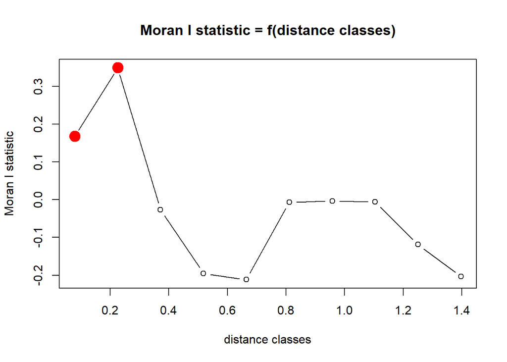

```r
maxDist<-max(dist(cbind(ken_sth$long, ken_sth$lat)))
xy=cbind(ken_sth$long, ken_sth$lat)
pgi.cor <- correlog(coords=xy, z=ken_sth$asc_prev, method="Moran", nbclass=10)
pgi_cor <- plot(pgi.cor)
```

We see that the Moran’s I statistic is highest at the `0.22` lag, with an I Statistic of 0.34 and p-value of `4.445339e-07` which is statistically significant. This suggests that that clustering is highest at the `0.22` spatial lag.

| dist.class | coef | p.value | n |
| --- | --- | --- | --- |
| 0.07951259 | 0.167804852 | 1.738061e-04 | 1392 |
| 0.22586721 | 0.349667575 | 4.445339e-07 | 344 |
| 0.37222133 | -0.026607805 | 5.533752e-01 | 490 |
| 0.51857545 | -0.195690567 | 9.996678e-01 | 1268 |
| 0.66492958 | -0.211641813 | 9.975709e-01 | 406 |
| 0.81128370 | -0.006777367 | 4.535831e-01 | 200 |
| 0.95763782 | -0.003560354 | 4.385098e-01 | 214 |
| 1.10399194 | -0.005979961 | 3.794849e-01 | 46 |
| 1.25034606 | -0.118840003 | 7.762726e-01 | 54 |
| 1.39670019 | -0.203928618 | 4.459248e-01 | 8 |

## Local Clustering

We find six points that are statistically significant outliers using the p-values of Local Moran’s I Statistic. These points are visualized in the plot below.

```r
coords<-coordinates(xy)
IDs<-row.names(as.data.frame(coords))
Neigh_nb<-knn2nb(knearneigh(coords, k=1, longlat = TRUE), row.names=IDs)
dsts<-unlist(nbdists(Neigh_nb,coords))
max_1nn<-max(dsts)


Neigh_kd1<-dnearneigh(coords,d1=0, d2=max_1nn, row.names=IDs)

weights<-nb2listw(Neigh_kd1, style="W")


I <-localmoran(ken_sth$asc_prev, weights)
Coef<-printCoefmat(data.frame(I[IDs,], row.names=row.names(coords),
                              check.names=FALSE))
```

```
##                Ii        E.Ii      Var.Ii    Z.Ii Pr(z != E(Ii))
##  [1,]  1.2089e+00 -6.7779e-02  1.1398e-01  3.7816      0.0001558 ***
##  [2,]  4.1688e-01 -6.7469e-03  1.1328e-02  3.9802      6.887e-05 ***
##  [3,]  1.1101e+00 -8.4877e-02  1.1565e-01  3.5139      0.0004415 ***
##  [4,]  1.2863e+00 -1.2322e-01  1.6086e-01  3.5145      0.0004406 ***
##  [5,]  7.0497e-01 -2.4159e-02  3.7386e-02  3.7709      0.0001626 ***
##  [6,] -8.6766e-01 -2.2591e-02  3.9829e-02 -4.2344      2.292e-05 ***
##  [7,]  1.4968e-02 -6.5790e-06  1.2678e-05  4.2055      2.605e-05 ***
##  [8,] -1.5923e-01 -7.2343e-04  1.3931e-03 -4.2467      2.170e-05 ***
##  [9,] -1.2093e-01 -4.1986e-04  8.0876e-04 -4.2374      2.261e-05 ***
## [10,] -1.9024e-01 -1.2160e-03  2.1909e-03 -4.0383      5.384e-05 ***
## [11,]  1.0238e+00 -3.7500e-02  6.9555e-02  4.0243      5.715e-05 ***
## [12,] -6.0074e-01 -9.6220e-03  1.8364e-02 -4.3621      1.288e-05 ***
## [13,]  4.6619e-01 -1.2006e-02  1.7661e-02  3.5984      0.0003202 ***
## [14,]  1.1410e-01 -4.6346e-04  8.3563e-04  3.9633      7.392e-05 ***
```

[output cut: 55 more lines]

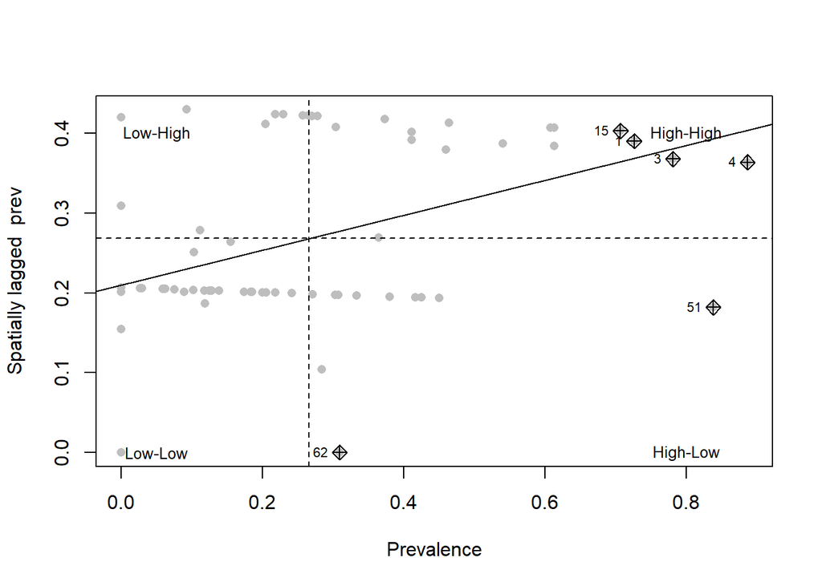

```r
nci<-moran.plot(ken_sth$asc_prev, listw=weights,
                xlab="Prevalence", ylab="Spatially lagged  prev", labels=T, pch=16, col="grey")
text(c(0.8,0.8, 0.05,0.05),c(0.4, 0,0.4,0), c("High-High", "High-Low", "Low-High", "Low-Low"), cex=0.8)
```

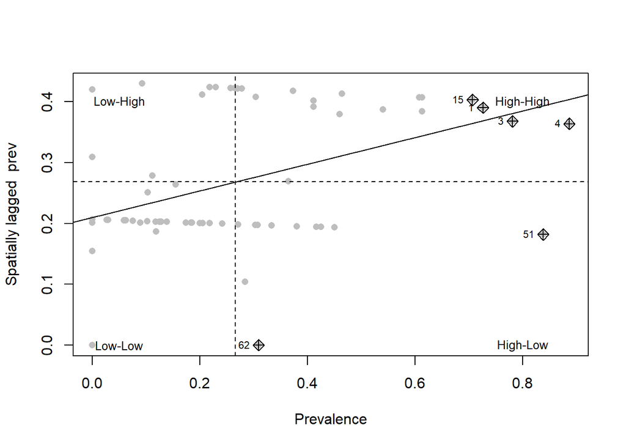

```r
nci <- moran.plot(ken_sth$asc_prev, listw=weights,
                xlab="Prevalence", ylab="Spatially lagged  prev", labels=T, pch=16, col="grey")
text(c(0.8,0.8, 0.05,0.05),c(0.4, 0,0.4,0), c("High-High", "High-Low", "Low-High", "Low-Low"), cex=0.8)
```

We can also plot these points on the map below.

```r
infl<-nci$is_inf==T


x<-ken_sth$asc_prev
lhx<-cut(x, breaks=c(min(x), mean(x), max(x)), labels=c("L", "H"), include.lowest=T)

wx<-stats::lag(weights,ken_sth$asc_prev)
lhwx<-cut(wx, breaks=c(min(wx), mean(wx), max(wx)), labels=c("L", "H"), include.lowest=T)
lhlh<-interaction(lhx,lhwx,infl,drop=T)

names<-rep("none", length(lhlh))
names[lhlh=="L.L.TRUE"]<-"LL"
names[lhlh=="H.L.TRUE"]<-"HL"
names[lhlh=="L.H.TRUE"]<-"LH"
names[lhlh=="H.H.TRUE"]<-"HH"


ken_sth_localM<-as.data.frame(cbind(xy,names))
colnames(ken_sth_localM)<-c("long", "lat", "names")
ken_sth_localM[c("long", "lat")] <- lapply( ken_sth_localM[c("long", "lat")], function(x) as.numeric(as.character(x)) )
factpal <- colorFactor(c( "cyan4","coral4","coral","cyan","lightgrey"), names)
leaflet_local_clustering <- leaflet(ken_sth_localM) %>% addTiles() %>% addCircleMarkers(~long, ~lat, fillOpacity=1,
                                                               color= ~factpal(names), radius=4, stroke=TRUE, weight=1) %>%
  addLegend(pal = factpal, values = ~names, title="Class")
leaflet_local_clustering
```

[interactive chart not shown]

The High-High points are primarily found in the Busia district, whereas the High-Low points are found in the Siaya and the Kisii district.

# Regression

We first run non-spatial regression and visualize the autocorrelation in the residuals. Below is a summary of the model.

```r
m1 <- spaMM::fitme(cbind(asc_np, stoolsexaminedgeo - asc_np) ~ temp + nl, data=ken_sth, family=binomial())
summary(m1)
```

```
## formula: cbind(asc_np, stoolsexaminedgeo - asc_np) ~ temp + nl
## Estimation of fixed effects by ML.
## family: binomial( link = logit )
##  ------------ Fixed effects (beta) ------------
##             Estimate Cond. SE t-value
## (Intercept) -4.31280 0.665459  -6.481
## temp         0.01718 0.002789   6.160
## nl          -0.13152 0.053824  -2.444
##  ------------- Likelihood values  -------------
##                         logLik
## p(h)   (Likelihood): -857.4244
```

Below we plot the Moran’s I Statistic for the residuals.

```r
nbc <- 10
cor_r <- pgirmess::correlog(coords = ken_sth[,c("long", "lat")],
                            z = residuals(m1),
                            method="Moran", nbclass=nbc)
```

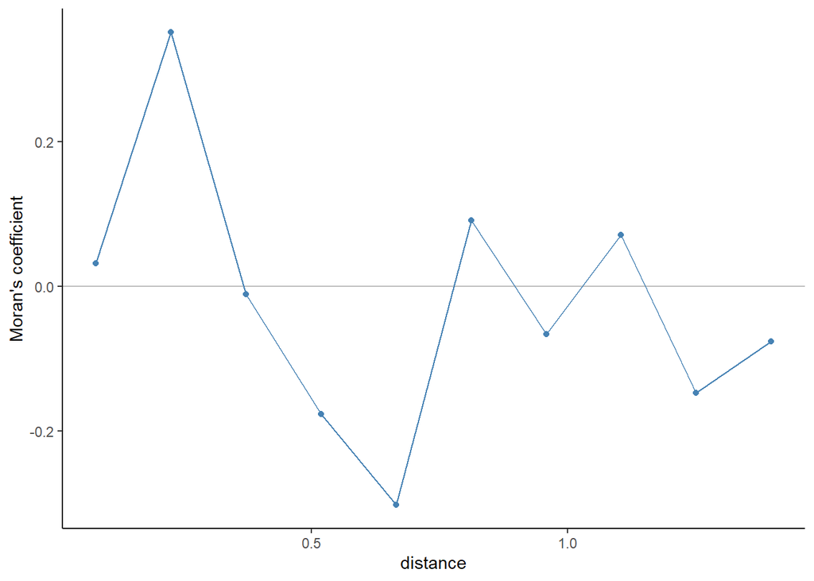

```r
correlograms <- as.data.frame(cor_r)
correlograms$variable <- "residuals_glm"

global_plot <- ggplot(subset(correlograms, variable=="residuals_glm"), aes(dist.class, coef)) +
  geom_hline(yintercept = 0, col="grey") +
  geom_line(col="steelblue") +
  geom_point(col="steelblue") +
  xlab("distance") +
  ylab("Moran's coefficient")+
  theme(panel.grid.major = element_blank(), panel.grid.minor = element_blank(),
        panel.background = element_blank(), axis.line = element_line(colour = "black"))

global_plot
```

We see that there is some spatial autocorrelation.

| dist.class | coef | p.value | n |
| --- | --- | --- | --- |
| 0.07951259 | 0.03156609 | 1.764334e-01 | 1392 |
| 0.22586721 | 0.35160734 | 3.597326e-07 | 344 |
| 0.37222133 | -0.01103201 | 4.671862e-01 | 490 |
| 0.51857545 | -0.17638264 | 9.988291e-01 | 1268 |
| 0.66492958 | -0.30272720 | 9.999813e-01 | 406 |
| 0.81128370 | 0.09135348 | 1.135677e-01 | 200 |
| 0.95763782 | -0.06605571 | 7.097162e-01 | 214 |
| 1.10399194 | 0.07085729 | 1.742544e-01 | 46 |
| 1.25034606 | -0.14760408 | 8.395085e-01 | 54 |
| 1.39670019 | -0.07633990 | 3.407428e-01 | 8 |

We next build a spatial regression model.

In the spatial regression model, We look for autocorrelation of errors in the spatial model using Moran I Statistic and find that it is not statistically significant at the 10% level for any spatial lag. This suggests that a spatial model is appropriate.

```r
m2 <- spaMM::fitme(cbind(asc_np, stoolsexaminedgeo - asc_np) ~ temp + nl + Matern(1|lat+long), data=ken_sth, family=binomial())
summary(m2)
```

```
## formula: cbind(asc_np, stoolsexaminedgeo - asc_np) ~ temp + nl + Matern(1 |
##     lat + long)
## Estimation of corrPars and lambda by Laplace ML approximation (p_v).
## Estimation of fixed effects by Laplace ML approximation (p_v).
## Estimation of lambda by 'outer' ML, maximizing p_v.
## family: binomial( link = logit )
##  ------------ Fixed effects (beta) ------------
##              Estimate Cond. SE  t-value
## (Intercept) -4.488637 10.93425 -0.41051
## temp         0.004825  0.05138  0.09390
## nl          -0.007482  0.22724 -0.03292
##  --------------- Random effects ---------------
## Family: gaussian( link = identity )
##                    --- Correlation parameters:
##      1.nu     1.rho
## 0.6552121 6.6581468
##            --- Variance parameters ('lambda'):
## lambda = var(u) for u ~ Gaussian;
##    lat + long  :  9.749
## # of obs: 67; # of groups: lat + long, 67
##  ------------- Likelihood values  -------------
##                         logLik
## p_v(h) (marginal L): -238.6128
```

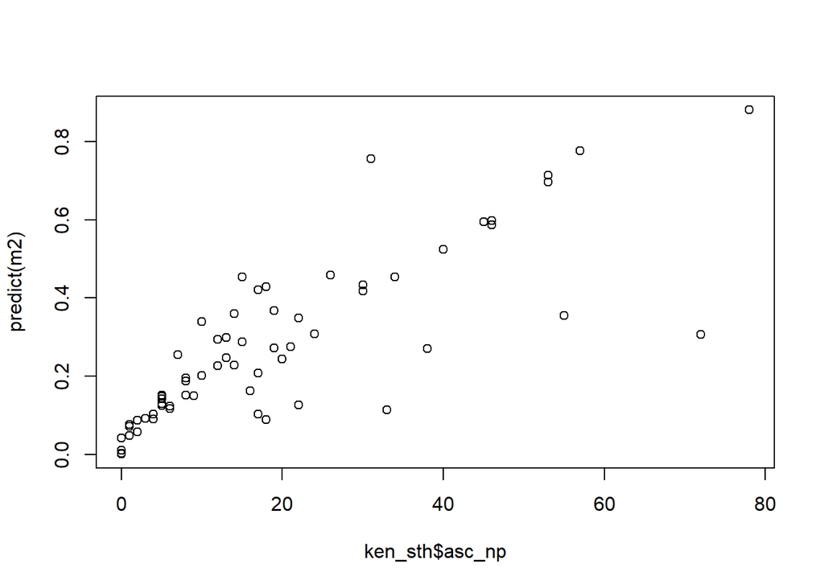

```r
plot(ken_sth$asc_np, predict(m2))
```

```r
summary(m2)
```

```
## formula: cbind(asc_np, stoolsexaminedgeo - asc_np) ~ temp + nl + Matern(1 |
##     lat + long)
## Estimation of corrPars and lambda by Laplace ML approximation (p_v).
## Estimation of fixed effects by Laplace ML approximation (p_v).
## Estimation of lambda by 'outer' ML, maximizing p_v.
## family: binomial( link = logit )
##  ------------ Fixed effects (beta) ------------
##              Estimate Cond. SE  t-value
## (Intercept) -4.488637 10.93425 -0.41051
## temp         0.004825  0.05138  0.09390
## nl          -0.007482  0.22724 -0.03292
##  --------------- Random effects ---------------
## Family: gaussian( link = identity )
##                    --- Correlation parameters:
##      1.nu     1.rho
## 0.6552121 6.6581468
##            --- Variance parameters ('lambda'):
## lambda = var(u) for u ~ Gaussian;
##    lat + long  :  9.749
## # of obs: 67; # of groups: lat + long, 67
##  ------------- Likelihood values  -------------
##                         logLik
## p_v(h) (marginal L): -238.6128
```

```r
cor_g <- pgirmess::correlog(coords=ken_sth[,c("long", "lat")],
                            z=residuals(m2),
                            method="Moran", nbclass=nbc)
cor_g
```

```
## Moran I statistic
##       dist.class         coef   p.value    n
##  [1,] 0.07951259 -0.063434261 0.8293129 1392
##  [2,] 0.22586721  0.052174806 0.1703072  344
##  [3,] 0.37222133  0.045657898 0.1862588  490
##  [4,] 0.51857545 -0.026783206 0.5872859 1268
##  [5,] 0.66492958 -0.003489024 0.4327243  406
##  [6,] 0.81128370 -0.012964708 0.4809194  200
##  [7,] 0.95763782 -0.032108064 0.5675438  214
##  [8,] 1.10399194  0.037002217 0.2828800   46
##  [9,] 1.25034606 -0.097053540 0.6830497   54
## [10,] 1.39670019 -0.183882944 0.4398920    8
```

```r
cor_g <- as.data.frame(cor_g)
as.data.frame(cor_g)
```

| dist.class | coef | p.value | n |
| --- | --- | --- | --- |
| 0.07951259 | -0.063434261 | 0.8293129 | 1392 |
| 0.22586721 | 0.052174806 | 0.1703072 | 344 |
| 0.37222133 | 0.045657898 | 0.1862588 | 490 |
| 0.51857545 | -0.026783206 | 0.5872859 | 1268 |
| 0.66492958 | -0.003489024 | 0.4327243 | 406 |
| 0.81128370 | -0.012964708 | 0.4809194 | 200 |
| 0.95763782 | -0.032108064 | 0.5675438 | 214 |
| 1.10399194 | 0.037002217 | 0.2828800 | 46 |
| 1.25034606 | -0.097053540 | 0.6830497 | 54 |
| 1.39670019 | -0.183882944 | 0.4398920 | 8 |

We can also look at the correlogram plot and we see that the spatial model has Moran’s I statistic that are closer to zero than the non-spatial model.

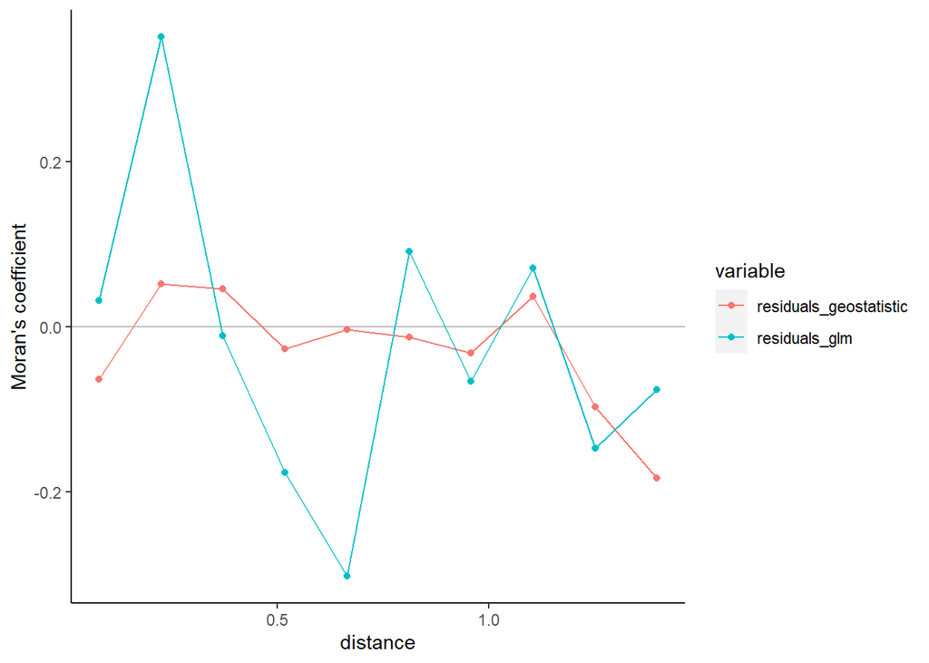

We now see the coefficients for the covariates.

```
## formula: cbind(asc_np, stoolsexaminedgeo - asc_np) ~ temp + nl + Matern(1 |
##     lat + long)
## Estimation of corrPars and lambda by Laplace ML approximation (p_v).
## Estimation of fixed effects by Laplace ML approximation (p_v).
## Estimation of lambda by 'outer' ML, maximizing p_v.
## family: binomial( link = logit )
##  ------------ Fixed effects (beta) ------------
##              Estimate Cond. SE  t-value
## (Intercept) -4.488637 10.93425 -0.41051
## temp         0.004825  0.05138  0.09390
## nl          -0.007482  0.22724 -0.03292
##  --------------- Random effects ---------------
## Family: gaussian( link = identity )
##                    --- Correlation parameters:
##      1.nu     1.rho
## 0.6552121 6.6581468
##            --- Variance parameters ('lambda'):
## lambda = var(u) for u ~ Gaussian;
##    lat + long  :  9.749
## # of obs: 67; # of groups: lat + long, 67
##  ------------- Likelihood values  -------------
##                         logLik
## p_v(h) (marginal L): -238.6128
```

None of the covariates are significant in the spatial model.

# Prediction

The analysis also allows us to make Roundworm prevalence predictions. We plot below the predictions from the spatial and the non-spatial model.

Predictions from the non-spatial model:

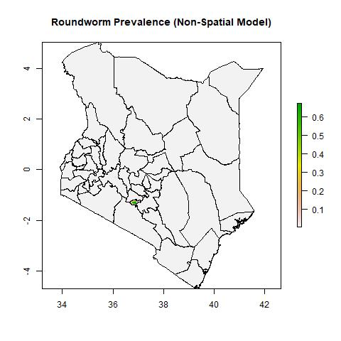

Predictions from the spatial model:

[figure not shown]

[figure not shown]

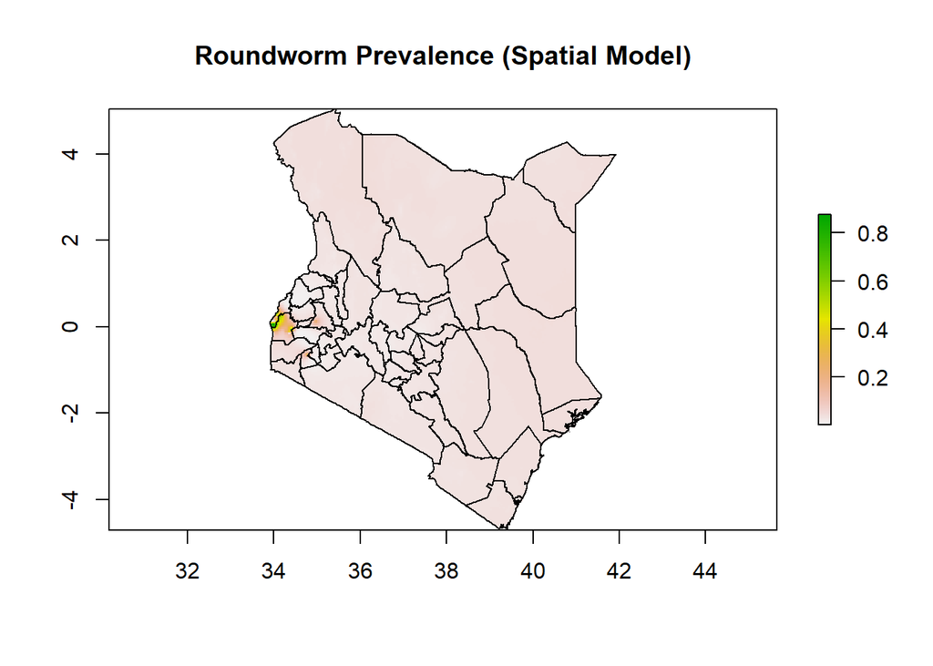

```r
# Spatial Model
predicted_prevalence_raster <- predict(pred_stack, m2)
predicted_prevalence_raster_ken <- mask(predicted_prevalence_raster, ken_adm)
plot(predicted_prevalence_raster_ken,main="Roundworm Prevalence (Spatial Model)")
lines(ken_adm)
```

# Discussion

This finding is also reflected in the regression model. The non-spatial model has a significant amount of spatial autocorrelation which goes away when we model using a spatial regression model.

# Conclusion

We conduct a spatial analysis of Roundworm prevalence in Kenya and find high levels of spatial clustering. We find that nightlights have a statistically significant effect on the prevalence, which however goes away, when we control for spatial autocorrelation. Further analysis that explores additional socio-economic variables is required to understand the drivers of the spatial clustering of prevalence that this analysis has shown.

# References

- Baird, S., Hicks, J. H., Kremer, M., & Miguel, E. (2015). Worms at Work: Long-run Impacts of a Child Health Investment (Working Paper No. 21428; Working Paper Series). National Bureau of Economic Research. https://doi.org/10.3386/w21428
- CDC. (2022, January 31). CDC - Soil-Transmitted Helminths. https://www.cdc.gov/parasites/sth/index.html
- Earth Observation Group—Defense Meteorological Satellite Progam, Boulder | ngdc.noaa.gov. (n.d.). Retrieved May 2, 2022, from https://ngdc.noaa.gov/eog/dmsp/downloadV4composites.html
- Jean, N., Burke, M., Xie, M., Davis, W. M., Lobell, D. B., & Ermon, S. (2016). Combining satellite imagery and machine learning to predict poverty. Science, 353(6301), 790–794. https://doi.org/10.1126/science.aaf7894
- Pullan, R. L., Gething, P. W., Smith, J. L., Mwandawiro, C. S., Sturrock, H. J. W., Gitonga, C. W., Hay, S. I., & Brooker, S. (2011). Spatial Modelling of Soil-Transmitted Helminth Infections in Kenya: A Disease Control Planning Tool. PLoS Neglected Tropical Diseases, 5(2), e958. https://doi.org/10.1371/journal.pntd.0000958
- Scholte, R. G. C., Schur, N., Bavia, M. E., Carvalho, E. M., Chammartin, F., Utzinger, J., & Vounatsou, P. (2013). Spatial analysis and risk mapping of soil-transmitted helminth infections in Brazil, using Bayesian geostatistical models. Geospatial Health, 8(1), 97–110. https://doi.org/10.4081/gh.2013.58
- WorldClim. (n.d.). Retrieved May 2, 2022, from https://www.worldclim.org/